# Модуль Б. Разработка модели машинного обучения

## Импортирование библиотек

```python
# библиотека с предобученной моделью YOLO
from ultralytics import YOLO

# библиотеки для обработки и анализа изображений
import cv2

# библиотека для визуализации изображений и графиков
import matplotlib.pyplot as plt

# библиотека для обучения на видеокарте
import torch

# библиотека для модели распознавания
from deepface import DeepFace

# библиотека для работы с датафреймами
import pandas as pd

# для работы с массивами и математическими операциями
import numpy as np

# библиотека для работы с файловой системой
import os
```

```
WARNING:tensorflow:From d:\Helper\MLBazyak\chemp\.venv\Lib\site-packages\tf_keras\src\losses.py:2976: The name tf.losses.sparse_softmax_cross_entropy is deprecated. Please use tf.compat.v1.losses.sparse_softmax_cross_entropy instead.
```

Определяем устройство, на котором будут производиться вычисления (CPU или GPU)

```python
device = torch.device('cuda' if torch.cuda.is_available() else 'cpu')
print(device)
```

```
cpu
```

**Основная задача нейронной сети - `определение и распознавание человеческих лиц на фотографии`. Для того чтобы решить эту задачу, нужно реализовать 2 модели:**

- Модель детекции лица
- Модель распознавания лица

## Подбор алгоритма обучения

Существуют несльколько различных предобученных моделей детекции, такие как:

- `EfficientNet`
- `ResNet`
- `YOLO`
- и многие другие

**В качестве модели для своей задачи, я буду использовать предобученную модель `YOLOv8n` (где n - nano) - это легкая и достаточно точная модель, которая способна решать задачи `детекции`, а так же в качестве улучшенной версии можно использовать `YOLOv8m` (где m - medium), как более мощную модель**

**YOLOv8 была выбрана благодаря её специализации на задачах детекции, что обеспечивает высокую точность и скорость работы**

**Модель YOLOv8n идеально подходит для устройств с ограниченными вычислительными ресурсами, сохраняя при этом высокое качество детекции**

**В случае необходимости повышения точности можно легко перейти на более крупные версии модели, такие как YOLOv8m, что делает YOLOv8 гибким и масштабируемым решением**

Для начала, надо загрузить сам предобученную модель в формате `.pt`

**В качестве модели для распознавания лица *(а именно для извлечения эмббедингов)* я буду использовать модель `FaceNet-512` из библиотеки `DeepFace`, так как она показывает наилучшие результаты:**

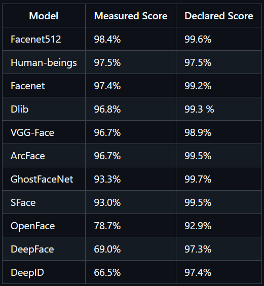

## Импорт данных для обучения нейронной сети

Для того чтобы передать данные `модели детекции`, на которых она будет обучаться, я буду использовать файл конфигурации формата `.yaml`:

**Структура `.yaml` файла**

```
path: C:\Users\user1\Project\some_data\face_rec_data\face_det # путь к основной папке с данными
train: train/images                                           # папка с тренировочными изображениями
val: valid/images                                             # папка с тестовыми изображениями
test: test/images                                             # папка с изображениями для валидации

# параметры аугментации
augment: True
hsv_h: 0.015    # изменение оттенка
hsv_s: 0.7      # изменение насыщенности
hsv_v: 0.4      # изменение яркости

degrees: 30     # поворот ±10 градусов
translate: 0.1  # смещение на 10% от размера изображения
scale: 0.5      # масштабирование от 50% до 150%
shear: 0.2      # сдвиг на ±20 градусов
flipup: 0.1
fliplr: 0.1

# оптимизация обучения
cache: disk     # кэширование данных на диск для ускорения обучения

patience: 5     # количество эпох без улучшения, после которых обучение останавливается

# количество и имя классов
nc: 1
names: ['face']
```

**Для `модели распознавания` в свою очередь, я буду использовать предобработанные в первом модуле данные из папки `...\Project\some_data\face_rec_data\face_ind`**

```python
# определяем пути для трех датасетов, которые были предобработанны в первом модуле
train_dir = r'C:\Users\user1\Project\some_data\face_rec_data\face_ind\train'
test_dir = r'C:\Users\user1\Project\some_data\face_rec_data\face_ind\test'
valid_dir = r'C:\Users\user1\Project\some_data\face_rec_data\face_ind\valid'
```

## Обучение нейронной сети

*обучение модели происходило на компьютере, поэтому `device - GPU`*

```python
# инициализируем модель YOLOv8 nano
model = YOLO('yolov8n.pt')
```

```
Downloading https://github.com/ultralytics/assets/releases/download/v8.3.0/yolov8n.pt to 'yolov8n.pt'...
```

*Для начала, попробую обучить модель на 2х эпохах*

```python
# тестовое обучение 1
results_test = model.train(
    data = r'C:\Users\user1\Project\face_recognition\Module_2\data.yaml',       # путь к yaml файлу
    epochs=2,                                                                   # количество эпох
    imgsz=640,                                                                  # размер изображений
    batch=-1,                                                                   # количество батчей (-1: подбераются наиболее оптимальный размер батча)
    device=device,                                                              # девайс (GPU или CPU)
    cos_lr=True,                                                                # косинусный планировщик кривой скорости обучении
    lr0=0.01,                                                                   # скорость обучения
    name='face_detection_v1'                                                    # название эксперимента
)
```

*полное перечисление гиперпараметров можно найти в файле `...\face_recognition\runs\detect\face_detection_v1\args.yaml`*

*Основные моменты обучения модели*

```
txt
Starting training for 2 epochs...

      Epoch    GPU_mem   box_loss   cls_loss   dfl_loss  Instances       Size
        1/2      6.32G      1.263      2.396      1.683        110        640: 100%|██████████| 16/16 [00:10<00:00,  1.48it/s]
                 Class     Images  Instances      Box(P          R      mAP50  mAP50-95): 100%|██████████| 2/2 [00:05<00:00,  2.53s/it]
                   all        170        210          1     0.0181      0.749      0.497

      Epoch    GPU_mem   box_loss   cls_loss   dfl_loss  Instances       Size
        2/2      6.33G     0.8316      1.143      1.246        111        640: 100%|██████████| 16/16 [00:06<00:00,  2.37it/s]
                 Class     Images  Instances      Box(P          R      mAP50  mAP50-95): 100%|██████████| 2/2 [00:01<00:00,  1.02it/s]
                   all        170        210      0.982      0.763      0.912      0.715


2 epochs completed in 0.009 hours.
Optimizer stripped from c:\Users\user1\Project\face_recognition\runs\detect\face_detection_v1\weights\last.pt, 6.2MB
Optimizer stripped from c:\Users\user1\Project\face_recognition\runs\detect\face_detection_v1\weights\best.pt, 6.2MB

Validating c:\Users\user1\Project\face_recognition\runs\detect\face_detection_v1\weights\best.pt...
Ultralytics 8.3.58  Python-3.11.9 torch-2.5.1+cu124 CUDA:0 (NVIDIA GeForce RTX 2080 SUPER, 8192MiB)
Model summary (fused): 168 layers, 3,005,843 parameters, 0 gradients, 8.1 GFLOPs
                 Class     Images  Instances      Box(P          R      mAP50  mAP50-95): 100%|██████████| 2/2 [00:01<00:00,  1.16it/s]
                   all        170        210      0.982      0.763      0.912      0.715
Speed: 0.5ms preprocess, 2.6ms inference, 0.0ms loss, 2.5ms postprocess per image
Results saved to c:\Users\user1\Project\face_recognition\runs\detect\face_detection_v1
```

*Скачиваю модель `YOLOv8m`*

```python
model = YOLO('yolov8m.pt')
```

```
Downloading https://github.com/ultralytics/assets/releases/download/v8.3.0/yolov8m.pt to 'yolov8m.pt'...
```

*Пробую обучить модель на 20 эпохах*

```python
# тестовое обучение 2
results_test = model.train(
    data = r'C:\Users\user1\Project\face_recognition\Module_2\data.yaml',       # путь к yaml файлу
    epochs=20,                                                                  # количество эпох
    imgsz=640,                                                                  # размер изображений
    batch=-1,                                                                   # количество батчей (-1: подбераются наиболее оптимальный размер батча)
    device=device,                                                              # девайс (GPU или CPU)
    cos_lr=True,                                                                # косинусный планировщик кривой скорости обучении
    lr0=0.01,                                                                   # скорость обучения
    name='face_detection_v2'                                                    # название эксперимента
)
```

*полное перечисление гиперпараметров можно найти в файле `...\face_recognition\runs\detect\face_detection_v2\args.yaml`*

*Основные моменты обучения модели*

```
txt
Starting training for 20 epochs...

      Epoch    GPU_mem   box_loss   cls_loss   dfl_loss  Instances       Size
       1/20       4.1G       1.09      1.194      1.487         27        640: 100%|██████████| 88/88 [00:19<00:00,  4.59it/s]
                 Class     Images  Instances      Box(P          R      mAP50  mAP50-95): 100%|██████████| 10/10 [00:01<00:00,  5.41it/s]
                   all        170        210    0.00915      0.724    0.00816    0.00555


      Epoch    GPU_mem   box_loss   cls_loss   dfl_loss  Instances       Size
       2/20      4.08G      1.119      1.004      1.451         25        640: 100%|██████████| 88/88 [00:18<00:00,  4.78it/s]
                 Class     Images  Instances      Box(P          R      mAP50  mAP50-95): 100%|██████████| 10/10 [00:01<00:00,  5.66it/s]
                   all        170        210     0.0459     0.0143    0.00104   0.000414


      ...


      Epoch    GPU_mem   box_loss   cls_loss   dfl_loss  Instances       Size
      10/20      3.98G      0.898     0.6165      1.289         22        640: 100%|██████████| 88/88 [00:18<00:00,  4.82it/s]
                 Class     Images  Instances      Box(P          R      mAP50  mAP50-95): 100%|██████████| 10/10 [00:01<00:00,  5.66it/s]
                   all        170        210      0.987      0.862      0.927      0.719

Closing dataloader mosaic
albumentations: Blur(p=0.01, blur_limit=(3, 7)), MedianBlur(p=0.01, blur_limit=(3, 7)), ToGray(p=0.01, num_output_channels=3, method='weighted_average'), CLAHE(p=0.01, clip_limit=(1.0, 4.0), tile_grid_size=(8, 8))

      Epoch    GPU_mem   box_loss   cls_loss   dfl_loss  Instances       Size
      11/20      3.99G     0.8455     0.5734      1.367          9        640: 100%|██████████| 88/88 [00:18<00:00,  4.83it/s]
                 Class     Images  Instances      Box(P          R      mAP50  mAP50-95): 100%|██████████| 10/10 [00:01<00:00,  5.66it/s]
                   all        170        210       0.93       0.88      0.929       0.71


      ...


      Epoch    GPU_mem   box_loss   cls_loss   dfl_loss  Instances       Size
      19/20      3.98G     0.6479     0.3895      1.172         10        640: 100%|██████████| 88/88 [00:18<00:00,  4.78it/s]
                 Class     Images  Instances      Box(P          R      mAP50  mAP50-95): 100%|██████████| 10/10 [00:01<00:00,  5.72it/s]
                   all        170        210      0.986      0.905      0.942      0.773


      Epoch    GPU_mem   box_loss   cls_loss   dfl_loss  Instances       Size
      20/20      4.08G     0.6377     0.3798      1.166          9        640: 100%|██████████| 88/88 [00:18<00:00,  4.85it/s]
                 Class     Images  Instances      Box(P          R      mAP50  mAP50-95): 100%|██████████| 10/10 [00:01<00:00,  5.69it/s]
                   all        170        210       0.99      0.909      0.942      0.772


20 epochs completed in 0.130 hours.
Optimizer stripped from c:\Users\user1\Project\face_recognition\runs\detect\face_detection_v2\weights\last.pt, 52.0MB
Optimizer stripped from c:\Users\user1\Project\face_recognition\runs\detect\face_detection_v2\weights\best.pt, 52.0MB

Validating c:\Users\user1\Project\face_recognition\runs\detect\face_detection_v2\weights\best.pt...
Ultralytics 8.3.58  Python-3.11.9 torch-2.5.1+cu124 CUDA:0 (NVIDIA GeForce RTX 2080 SUPER, 8192MiB)
Model summary (fused): 218 layers, 25,840,339 parameters, 0 gradients, 78.7 GFLOPs
                 Class     Images  Instances      Box(P          R      mAP50  mAP50-95): 100%|██████████| 10/10 [00:01<00:00,  5.05it/s]
                   all        170        210      0.986      0.905      0.942      0.773
Speed: 0.2ms preprocess, 6.5ms inference, 0.0ms loss, 1.1ms postprocess per image
Results saved to c:\Users\user1\Project\face_recognition\runs\detect\face_detection_v2
```

На основании полученных метрик можно сделать вывод, что данная модель хорошо подходит для решения моей задачи. Модель демонстрирует высокие показатели качества детекции:

- `Precision (точность)`: 0.986 — это указывает на то, что 98,6% обнаруженных объектов являются верными
- `Recall (полнота)`: 0.905 — это означает, что модель обнаруживает 90,5% всех объектов на изображениях
- `mAP50`: при пороге IoU > 0.5 модель демонстрирует высокую среднюю точность, что подтверждает её способность точно локализовать объекты
- `mAP50-95`: 0.773 — даже при более строгих требованиях к точности bounding box (IoU от 0.5 до 0.95) модель показывает отличный результат, что свидетельствует о её стабильности и качестве

**Учитывая высокие значения метрик, можно заключить, что модель эффективно справляется с задачей детекции и подходит для использования в моем решении**

Батчи модели:

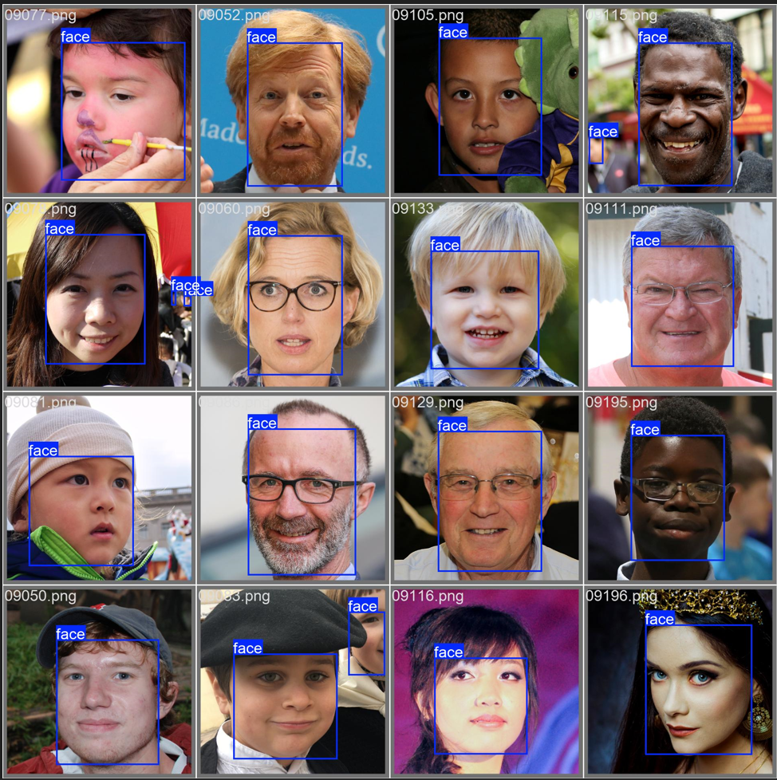

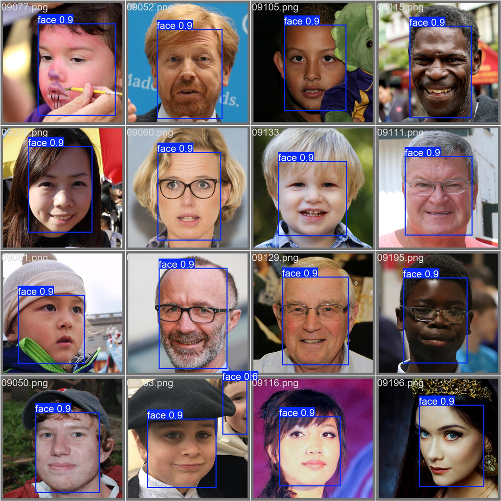

*более подробную информацию можно посмотреть в папке `...\face_recognition\runs\detect\face_detection_v2`*

Инициализируем модель детекции для дальнейшего использования

```python
model = YOLO(r'D:\Helper\MLBazyak\homework\face_recognition\runs\detect\face_detection_v2\weights\best.pt')
```

**После того как была реализованна модель детекции лица, надо реализовать алгоритм для распознавания человека на фотографии**

Для этого, надо извлечь `эмбеддинги` для каждого лица в наборе данных

*Функция для извлечения эмбеддинга из фотографии*

```python
def extract_embeddings(img_path: str,
                       det_model: YOLO,
                       rec_model: str = 'Facenet512'):
    '''
        Процедура для выгрузки эмбеддингов из фотографии

    Args:
        - img_path (str): Путь к изображению, на котором нужно найти лицо.
        - det_model (YOLO): Модель YOLO для обнаружения bounding box'ов лиц.
        - rec_model (str): Модель распознавания для выделения эмбеддингов лиц.

    Returns:
        list: Функция возвращает ембеддинг в формате списка.
    '''
    # приводим изображение в удобный формат
    image = cv2.imread(img_path)
    # проверяем, точно ли мы получаем изображение
    if image is None:
        print(f"Ошибка: изображение по пути {img_path} не найдено или не может быть загружено.")
        return np.nan

    # используя модель детекции, находим лицо на изображении
    res = det_model.predict(image, conf=0.3, iou=0.2)

    # проверка, найдены ли bounding box'ы
    if len(res[0].boxes) == 0:
        return np.nan  # если лицо не найдено, возвращаем np.nan

    # проходимся по результатам детекции
    for result in res:
        boxes = result.boxes.xyxy.cpu().numpy()
        for box in boxes:
            x1,y1,x2,y2 = map(int, box)
            # обрезаем исходное изображение, оставляя только лицо
            crop = image[y1:y2, x1:x2]
            # пробуем извлечь из полученного лица эмбеддинг
            try:
                emb_obj = DeepFace.represent(
                    img_path=crop,
                    model_name=rec_model
                )
            # при неудачном извлечении, выводим ошибку
            except Exception as e:
                print(f'Exception: {e}')
                return np.nan
    # так как DeepFace.represent() возвращает список словарей, надо оставить только нужные нам данные
    emb_obj = np.array(emb_obj[0]['embedding']).reshape(1,-1)
    # возвращаем полученный эмбеддинг
    return emb_obj
```

[output not shown]

*Так как в последствии надо будет искать наиболее похожий эмбеддинг среди всех имеющихся, надо реализовать функцию, которая будет извлекать и сохранять их в базу данных формата `.pickle`*

```python
def extract_all_emb(start_path: str, df_name: str):
    '''
        Процедура для выгрузки эмбеддингов из всей папки

    Args:
        - start_path (str): Путь к папке с изображениями
        - df_name (str): Название для сохранения базы данных.
    '''
    # создаем датафрэйм используя pandas
    df = pd.DataFrame(columns=['name', 'img_path', 'embedding'])
    # инициализируем счетчик фотографий
    ind = 0
    # проходимся по каждому имени в папке
    for name in os.listdir(start_path):
        # логирование (выводим имя папки)
        print(name)
        # назначаем путь с именной папкой
        name_path = os.path.join(start_path, name)
        # проходимся по каждой фотографии внутри папки с именем
        for img in os.listdir(name_path):
            # сохраняем путь к изображению
            img_path = os.path.join(name_path, img)
            # выгружаем эмбеддинг
            embed = extract_embeddings(img_path, model)
            # сохраняем новую строку в базе данных
            df.loc[ind] = [name, img_path, embed]
            # обновляем счетчик
            ind+=1

    # логирование (выводим размер датафрейма)
    print(df.shape)
    df.to_pickle(f'{df_name}.pkl')
```

Извлекаем эмбеддинги из тренировочного датасета

```python
extract_all_emb(train_dir, 'train')
```

*пример вывода функции:*

```
txt
0: 640x640 1 face, 13.5ms
Speed: 15.6ms preprocess, 13.5ms inference, 3.0ms postprocess per image at shape (1, 3, 640, 640)
Alexander_Downer

0: 640x640 1 face, 15.6ms
Speed: 0.0ms preprocess, 15.6ms inference, 0.0ms postprocess per image at shape (1, 3, 640, 640)
Alexander_Losyukov

0: 640x640 1 face, 19.2ms
Speed: 0.0ms preprocess, 19.2ms inference, 0.0ms postprocess per image at shape (1, 3, 640, 640)
Alexandra_Stevenson

0: 640x640 1 face, 28.8ms
Speed: 0.0ms preprocess, 28.8ms inference, 0.0ms postprocess per image at shape (1, 3, 640, 640)
Alex_Sink

0: 640x640 2 faces, 74.2ms
Speed: 0.0ms preprocess, 74.2ms inference, 2.0ms postprocess per image at shape (1, 3, 640, 640)
Ali_Khamenei

0: 640x640 1 face, 77.8ms
Speed: 0.0ms preprocess, 77.8ms inference, 0.0ms postprocess per image at shape (1, 3, 640, 640)
Ali_Naimi

0: 640x640 1 face, 78.3ms
Speed: 0.0ms preprocess, 78.3ms inference, 0.0ms postprocess per image at shape (1, 3, 640, 640)
Allyson_Felix
```

Извлекаем эмбеддинги из тестового и валидационного датасета

```python
extract_all_emb(test_dir, 'test')
extract_all_emb(valid_dir, 'valid')
```

*пример вывода ячейки:*

```
txt
0: 640x640 1 face, 14.9ms
Speed: 4.0ms preprocess, 14.9ms inference, 2.0ms postprocess per image at shape (1, 3, 640, 640)
Abdoulaye_Wade

0: 640x640 1 face, 15.0ms
Speed: 15.6ms preprocess, 15.0ms inference, 0.0ms postprocess per image at shape (1, 3, 640, 640)

0: 640x640 1 face, 15.6ms
Speed: 0.0ms preprocess, 15.6ms inference, 0.0ms postprocess per image at shape (1, 3, 640, 640)
Abdullah

0: 640x640 1 face, 18.5ms
Speed: 0.0ms preprocess, 18.5ms inference, 0.0ms postprocess per image at shape (1, 3, 640, 640)

0: 640x640 1 face, 15.6ms
Speed: 0.0ms preprocess, 15.6ms inference, 0.0ms postprocess per image at shape (1, 3, 640, 640)
Abdullah_al-Attiyah

0: 640x640 3 faces, 15.6ms
Speed: 15.6ms preprocess, 15.6ms inference, 2.5ms postprocess per image at shape (1, 3, 640, 640)
Exception: Face could not be detected in numpy array.Please confirm that the picture is a face photo or consider to set enforce_detection param to False.

0: 640x640 1 face, 15.6ms
Speed: 1.4ms preprocess, 15.6ms inference, 0.0ms postprocess per image at shape (1, 3, 640, 640)
Abdullah_Gul
```

Загружаем полученные датафреймы

```python
# подгружаем сохраненные ранее датафреймы
train_df = pd.read_pickle(r'D:\Helper\MLBazyak\homework\face_recognition\Module_2\Data\train.pkl')
test_df = pd.read_pickle(r'D:\Helper\MLBazyak\homework\face_recognition\Module_2\Data\test.pkl')
val_df = pd.read_pickle(r'D:\Helper\MLBazyak\homework\face_recognition\Module_2\Data\valid.pkl')

# объединяем тестовый и валидационный датасет для проверок
test_df = pd.concat([test_df, val_df], ignore_index=True)
```

Выводим размерности датасетов

```python
print(f'Размер тренировочного датасета: {train_df.shape}')
print(f'Размер датасета для проверки: {test_df.shape}')
```

```
Размер тренировочного датасета: (4084, 4)
Размер датасета для проверки: (2468, 4)
```

*4 колонка - пути для изображениях на другом устройстве*

сохраняем итоговые датафреймы в формате `.pickle`

```python
train_df.to_pickle('Data/train.pkl')
test_df.to_pickle('Data/test.pkl')
```

## Разработка APi

**Все функции реализованны в файле `function.py` для удобства**

Для начала, надо реализовать `функцию получения фотографии`:

```
def get_photo(img_path: str,
              model: YOLO) -> tuple:
    '''
        Функция для получения фотографии (для последующего распознания)

    Args:
        - img_path (str): путь к фотографии

    Returns:
        - tuple (np.ndarray, str)
    '''
    # приводим изображение в удобный формат
    image = cv2.imread(img_path)
    # проверяем, точно ли мы получаем изображение
    if image is None:
        print(f"Ошибка: изображение по пути {img_path} не найдено или не может быть загружено.")
        return np.nan

    # используя модель детекции, находим лицо на изображении
    res = model.predict(image, conf=0.3, iou=0.2)

    # проверка, найдены ли bounding box'ы
    if len(res[0].boxes) == 0:
        print('no face`s')
        return np.nan  # если лицо не найдено, возвращаем np.nan
    # проверка, не больше ли 1 лица найдено
    if len(res[0].boxes) > 1:
        print('to many face`s')
        return np.nan  # если лицо не найдено, возвращаем np.nan

    # проходимся по результатам детекции
    for result in res:
        boxes = result.boxes.xyxy.cpu().numpy()
        for box in boxes:
            x1,y1,x2,y2 = map(int, box)
            # обрезаем исходное изображение, оставляя только лицо
            crop = image[y1:y2, x1:x2]

    return (crop, img_path)
```

*Теперь, реализуем функцию `для отправки результатов распознавания`*

```
def face_recognition(
        crop: np.ndarray,
        img_path: str,
        emb_df: pd.DataFrame
                     ) -> tuple:
    '''
        Функция для отправки результатов распознавания

    Args:
        - photo_info (np.ndarray): кроп детектированного лица
        - img_path (str): путь к изначальному изображению
        - emb_df (pd.DataFrame): датафрейм с известными эмбеддингами

    Returns:
        tuple (float, str, str, str)
    '''

    # вычисляем эмбеддинг входного изображения
    try:
        input_emb = DeepFace.represent(
                    img_path=crop,
                    model_name='Facenet512' # используем модель FaceNet512
                )
    # если эмбеддинг извлечь не удалось, выводим ошибку
    except Exception as e:
        print(f'Ошибка: {e}\nНевозможно извлечь эмбединг')
        return 'error'

    # так как DeepFace.represent() возвращает список словарей, нужно извлечь требуемые данные
    # и привести их в двумерный массив
    input_emb = np.array(input_emb[0]['embedding']).reshape(1,-1)
    # переменная, куда будут записываться максимальное сходство
    similar = 0
    # переменная, куда будет записываться имя человека, у которого максимальное сходство
    name = ''
    # пороговое значение для сходства (сходство не может быть меньше этого значения)
    treshold  = 0.5
    # переменная, куда будет записываться путь к изображению с максимальным сходством
    out_path = ''

    # проходимся по всему датафрейму
    for i in range(emb_df.shape[0]):
        # в датафреме данные по фотографии хранятся в виде списка словарей
        emb_list = emb_df['embedding'].iloc[i]
        # извлекаем эмбеддинг из списка словарей, и приводим его к 2d
        emb = np.array(emb_list[0]['embedding']).reshape(1,-1)
        # вычисляем косинусное сходство
        cos_sim = float(cosine_similarity(emb, input_emb))
        # обновляем переменные в зависимости от результата сравнения
        if cos_sim > similar:
            similar = cos_sim
            name = emb_df['name'].iloc[i]
            out_path = emb_df['img_path2'].iloc[i]

    # если изображение не прошло трешхолд, значит такого человека нет в базе данных
    if similar < treshold:
        print('Неизвестная личность')
        return 'unknown'
    # иначе, возвращаем результаты сходства в кортеже
    else:
        return (similar, name, img_path, out_path)
```

**Unit-тесты `get_photo()`**

*все тесты реализованны в файле `test_function.py`*

для начала, нужно импортировать все нужные нам библиотеки:

```
# библиотека, с реализоваными unit тестами
import unittest

# импортируем функцию из нашего модуля с API
from function import get_photo, face_recognition

# библиотека для математических операций
import numpy as np

# библиотека с предобученной моделью YOLO
from ultralytics import YOLO

# библиотека для работы с датафреймами
import pandas as pd

# модуль для отключения предупреждений
import warnings
warnings.filterwarnings("ignore")
```

инициализируем нужные нам пути, модели и тд:

```
# инициализация модели детекции
model = YOLO(r'D:\Helper\MLBazyak\homework\face_recognition\runs\detect\face_detection_v2\weights\best.pt')

# фотография с лицом
face = r'D:\Helper\MLBazyak\homework\face_recognition\Module_2\Data\putin.jpg'
# фотография без лица
no_face = r'D:\Helper\MLBazyak\homework\face_recognition\Module_2\Data\no_face_test.jfif'
# фотография с более чем 1 лицом
to_many_face = r'D:\Helper\MLBazyak\homework\face_recognition\Module_2\Data\to_many_test.jfif'
# фотография с неизвестным лицом
unknown = r'D:\Helper\MLBazyak\homework\face_recognition\Module_2\Data\uknown.jpg'
# фотография из которой не извлекается эмбеддинг
no_emb = r'D:\Helper\MLBazyak\homework\face_recognition\Module_2\Data\mikli.png'

# инициализируем датафрейм с эмбеддингами
df = pd.read_pickle(r'D:\Helper\MLBazyak\homework\face_recognition\Module_2\Data\train.pkl')
```

теперь нужно создать класс с тестами (для функции `get_photo()`), наследуя его от класса `unittest.TestCase`:

```
# функция get_photo()
class TestGetPhoto(unittest.TestCase):
    # тестирование случая, когда на фотографии есть лицо
    def test_face_true(self):
        self.assertTrue(type(get_photo(img_path=face, model=model)) == tuple)
        self.assertTrue(type(get_photo(img_path=face, model=model)[0]) == np.ndarray)
        self.assertTrue(type(get_photo(img_path=face, model=model)[1]) == str)

    # тестирование случая, когда на фотографии нет лица
    def test_face_false(self):
        self.assertTrue(type(get_photo(img_path=no_face, model=model)) == str)
        self.assertTrue(get_photo(img_path=no_face, model=model) == 'no_face')

    # тестирование случая, когда на фотографии больше 1 лица
    def test_to_many_face(self):
        self.assertTrue(type(get_photo(img_path=to_many_face, model=model)) == str)
        self.assertTrue(get_photo(img_path=to_many_face, model=model) == 'to_many')

    # проверка типов данных, принимаемых функцией get_photo()
    def test_data_type(self):
        # неправильно указан путь к фото
        with self.assertRaises(TypeError):
            get_photo(img_path=123, model=model)
        # неправильно указана модель детекции
        with self.assertRaises(TypeError):
            get_photo(img_path=face, model=123)
```

далее переходим к тестированию функции `face_recognition()`:

```
# функция face_recognition()
class TestFaceRecognition(unittest.TestCase):
    # тестирование случая, когда эмбеддинг успешно найден
    def test_emb_true(self):
        img_info = get_photo(face, model)
        self.assertTrue(type(face_recognition(img_info[0], img_info[1], df)) == tuple)
        self.assertTrue(type(face_recognition(img_info[0], img_info[1], df)[0]) == float)
        self.assertTrue(type(face_recognition(img_info[0], img_info[1], df)[1]) == str)
        self.assertTrue(type(face_recognition(img_info[0], img_info[1], df)[2]) == str)
        self.assertTrue(type(face_recognition(img_info[0], img_info[1], df)[3]) == str)

    # тестирование случая, при котором эмбеддинг находится, но в базе данных нет человека
    # со сохдстовом больше порогового (т.е. неизвестный нам человек)
    def test_emb_unknown(self):
        img_info = get_photo(unknown, model)
        self.assertTrue(type(face_recognition(img_info[0], img_info[1], df)) == str)
        self.assertTrue(face_recognition(img_info[0], img_info[1], df) == 'unknown')

    # тестирование случая, при котором не удается извлечь эмбеддинг
    def test_no_emb(self):
        img_info = get_photo(no_emb, model)
        self.assertTrue(type(face_recognition(img_info[0], img_info[1], df)) == str)
        self.assertTrue(face_recognition(img_info[0], img_info[1], df) == 'no_emb')

    # проверка на правильность типов данных, передоваемых функции
    def test_data_type(self):
        img_info = get_photo(face, model)
        # неправильно указан путь к фото
        with self.assertRaises(TypeError):
            get_photo(crop=img_info[0], img_path=123, emb_df=df)

        # неправильно указан путь к фото
        with self.assertRaises(TypeError):
            get_photo(crop=123, img_path=img_info[1], emb_df=df)

        # неправильно указан путь к фото
        with self.assertRaises(TypeError):
            get_photo(crop=img_info[0], img_path=img_info[1], emb_df=123)
```

прописываем инициализацию файла при запуске, чтобы не запускать через терминал:

```
if __name__ == "__main__":
    unittest.main()
```

Теперь можно запустить файл с тестами, и убедиться что все работает корректно:

[output not shown]

**Перед началом разработки API, проверим функции в действии:**

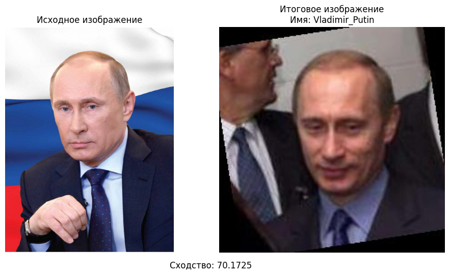

```python
# импортируем реализованные функции
from function import get_photo, face_recognition

# тестовая фотография из интернета
img = r'D:\Helper\MLBazyak\homework\face_recognition\Module_2\Data\putin.jpg'
# модель детекции
model = YOLO(r'D:\Helper\MLBazyak\homework\face_recognition\runs\detect\face_detection_v2\weights\best.pt')
# датафрейм с эмбеддингами
df = pd.read_pickle(r'D:\Helper\MLBazyak\homework\face_recognition\Module_2\Data\train.pkl')

# получаем кроп лица
face, path = get_photo(img, model)
# получаем результат распознавания
similar, name, path, out_path = face_recognition(face, path, df)

# визуализируем результат
img_input = cv2.cvtColor(cv2.imread(path), cv2.COLOR_BGR2RGB)
img_out = cv2.cvtColor(cv2.imread(out_path), cv2.COLOR_BGR2RGB)

# создаем график, состоящий из 2 картинок, входной и выходной
fig, ax = plt.subplots(1,2,figsize=(10,5))
# настраиваем первое изображение
ax[0].imshow(img_input)
ax[0].axis('off')
ax[0].set_title('Исходное изображение')
# настраиваем второе изображение
ax[1].imshow(img_out)
ax[1].axis('off')
ax[1].set_title(f'Итоговое изображение\nИмя: {name}')

fig.text(0.5, -0.03, f"Сходство: {similar*100:.4f}", ha='center', fontsize=12)

plt.tight_layout()
plt.show()
```

```python
# импортируем реализованные функции
from function import get_photo, face_recognition
```

```python
# Загрузка модели YOLO
model = YOLO(r'D:\Helper\MLBazyak\chemp\face_recognition\runs\detect\face_detection_v2\weights\best.pt')

# Загрузка датафрейма с эмбеддингами
emb_df = pd.read_pickle(r'D:\Helper\MLBazyak\chemp\face_recognition\Module_2\Data\train.pkl')
```

```python
# видео
video = cv2.VideoCapture(r'D:\Helper\MLBazyak\chemp\face_recognition\Module_2\Data\video.mp4')
# проверка на корректность видео файла
if not video.isOpened():
    print('Ошибка: видео не может быть открыто по указанному пути')
    exit()

tries = 0

while video.isOpened():
    ret, frame = video.read()
    if not ret:
        break

    # temp_path = 'frame_temp.jpg'
    # cv2.imwrite(temp_path, frame)

    result = get_photo(frame, model)

    if isinstance(result, tuple):
        crop, img_boxes = result
        cv2.imshow('Video', img_boxes)


    if tries == 0:
        test_rec = face_recognition(crop, 'test_path', emb_df)
        if isinstance(test_rec, tuple):
            similar, name, _, _ = test_rec
            tries+=1
            print(f'Распознанное имя: {name}\nСхожесть: {similar}')


    if cv2.waitKey(1) & 0xFF == ord('q'):
        break

video.release()
cv2.destroyAllWindows()
```

```
Распознанное имя: Thaksin_Shinawatra
Схожесть: 0.6384336418325434
```

```python
# Функция для обработки видео
def process_video(video_path: str, output_path: str):
    # Открываем видео
    cap = cv2.VideoCapture(video_path)
    if not cap.isOpened():
        print(f"Ошибка: видео по пути {video_path} не может быть открыто.")
        return

    # Получаем параметры видео (ширина, высота, FPS)
    width = int(cap.get(cv2.CAP_PROP_FRAME_WIDTH))
    height = int(cap.get(cv2.CAP_PROP_FRAME_HEIGHT))
    fps = int(cap.get(cv2.CAP_PROP_FPS))

    # Создаем VideoWriter для сохранения результата
    fourcc = cv2.VideoWriter_fourcc(*'mp4v')
    out = cv2.VideoWriter(output_path, fourcc, fps, (width, height))

    while cap.isOpened():
        ret, frame = cap.read()
        if not ret:
            break

        # Сохраняем временный кадр для обработки
        temp_frame_path = "temp_frame.jpg"
        cv2.imwrite(temp_frame_path, frame)

        # Обрабатываем кадр
        result = get_photo(temp_frame_path, model)
        if isinstance(result, tuple):
            crop, img_path, img_boxes = result
            # Распознаем лицо
            recognition_result = face_recognition(crop, img_path, emb_df)
            if isinstance(recognition_result, tuple):
                similar, name, _, _ = recognition_result
                # Добавляем текст с именем на кадр
                cv2.putText(img_boxes, f"{name} ({similar:.2f})", (10, 30), cv2.FONT_HERSHEY_SIMPLEX, 1, (0, 255, 0), 2)

            # Записываем кадр в выходное видео
            out.write(img_boxes)

        # Отображаем кадр (опционально)
        cv2.imshow("Video", img_boxes)
        if cv2.waitKey(1) & 0xFF == ord('q'):  # Выход по нажатию 'q'
            break

    # Освобождаем ресурсы
    cap.release()
    out.release()
    cv2.destroyAllWindows()

# Пример использования
process_video('input_video.mp4', 'output_video.mp4')
```

*После того, как мы убедились в работоспособности функций, можно приступить к реализации API*

**Для разработки `API` я буду использовать библиотеку `streamlit`, так как это удобный инструмент для быстрого развертывания небольших веб приложений**

*импортирую нужные мне модули и библиотеки:*

```
# библиотека для API
import streamlit as st

# библиотека с предобученной моделью YOLO
from ultralytics import YOLO

# библиотеки для обработки и анализа изображений
import cv2

# библиотека для модели распознавания
from deepface import DeepFace

# библиотека для работы с датафреймами
import pandas as pd

# для работы с массивами и математическими операциями
import numpy as np

# для вычисления косинусной схожести
from sklearn.metrics.pairwise import cosine_similarity

# библиотека для работы с файловой системой
import os

# реализованные мной функции распознавания
from function import get_photo, face_recognition
```

*После этого, надо инициализировать пути к изображениям, датафреймы и тд:*

```
# Инициализация модели и данных
model = YOLO(r'D:\Helper\MLBazyak\homework\face_recognition\runs\detect\face_detection_v2\weights\best.pt')
# пути к различным изображениям
no_face = r'D:\Helper\MLBazyak\homework\face_recognition\Module_2\Data\no_face.jpg'
to_many = r'D:\Helper\MLBazyak\homework\face_recognition\Module_2\Data\to_many.jpg'
dont_know = r'D:\Helper\MLBazyak\homework\face_recognition\Module_2\Data\dont_know.jpg'
# инициализация датафрейма с эмбеддингами
df = pd.read_pickle(r'D:\Helper\MLBazyak\homework\face_recognition\Module_2\Data\train.pkl')
# путь к датафрейму
df_path =r'D:\Helper\MLBazyak\homework\face_recognition\Module_2\Data\train.pkl'
```

*Реализация различных вспомогательных функций*

```
# Функция для отображения изображений
def output_images(path1: str, path2: str, caption2: str):
    # преобразование цветовой гаммы изображений
    img_rgb = cv2.cvtColor(cv2.imread(path1), cv2.COLOR_BGR2RGB)
    out_rgb = cv2.cvtColor(cv2.imread(path2), cv2.COLOR_BGR2RGB)
    # разделение на 2 части
    col1, col2 = st.columns(2)
    # вывод исходного изображения
    with col1:
        st.image(img_rgb, caption='Input image', use_container_width=True)
    # вывод итогового распознания
    with col2:
        st.image(out_rgb, caption=f'{caption2}', use_container_width=True)
```

*Теперь, можно перейти к созданию интерфейса:*

```
# название страницы
st.title('Расплознавание человека по фотографии')

# кнопка для скачивания справки по приложению
with open(r'D:\Helper\MLBazyak\homework\face_recognition\Module_2\Documentation.pdf', 'rb') as file:
    st.download_button(
        label='Справка',
        data=file,
        file_name='Справка.pdf',
        mime='application/pdf'
    )

# форма для загрузки фотографии
uploader = st.file_uploader('Выберите изображение',
                            type=['jpg', 'jpeg', 'png', 'jfif'])
# при загрузке изображения в форму:
if uploader is not None:
    user_img = 'user_img.jpg'
    # сохраняем файл как временный
    with open(user_img, 'wb') as f:
        f.write(uploader.getbuffer())
    # пробуем найти лицо на фотографии пользователя
    crop_test = get_photo(user_img, model)
    # проверка выполнения функции
    match crop_test:
        case str() if crop_test == 'to_many':
            output_images(user_img, to_many, 'Слишком много лиц на фотографии')

        case str() if crop_test == 'no_face':
            output_images(user_img, no_face, 'Лицо на фотографии не найдено')

        case tuple():
            # получаем кроп лица
            face, path = crop_test
            # пробуем получить данные о распознавании
            rec_test = face_recognition(face, path, df)

            # проверка выполнения функции
            match rec_test:
                # если фотография не прошла трешхолд схожести
                # (такого лица нет в базе данных)
                case str() if rec_test == 'unknown':
                    output_images(user_img, to_many, 'Такого человека нет в базе данных')

                # если не получилось извлечь эмбеддинг
                case str() if rec_test == 'no_emb':
                    output_images(user_img, no_face, 'Не удалось извлечь эмбеддинг лица\nПопробуйте загрузить фотографию с более четким лицом')

                # если все прошло успешно
                case tuple():
                    # получаем результат распознавания
                    similar, name, path, out_path = face_recognition(face, path, df)
                    # выводим результаты
                    output_images(user_img, out_path, f'Результат распознавания: {name}')

                    st.write(f'Сходство: {similar*100:.3f}')
```

**Таким образом, я реализовал API для использования и тестирования модели распознавания лица на фотографии**

**Чтобы запустить и использовать API, следует прописать в терминале `streamlit run путь\к\файлу.py`**

*пример команды:*

```
streamlit run Module_2/api2.py
```

после этого откроется браузер с запущенным приложением на локальном хосте

## Рефлексия

**В процессе выполнения модуля:**

**В дальнейшем, можно реализовать подгрузку собственных фотографий в базу данных через API (что я почти сделал), а также попробовать использовать более сложный алгоритм распознавания, например - `кластеризацию`**